# Daniel Davies - Politics&Information

## Kaohsiung Mayoral Campaigns 2018

### Total Amount of Posts

The below graph shows the frequency by which the Kaohsiung mayoral candidates Han Guo-Yu (韓國瑜) and Chen Chi-Mai (陳其邁) posted to Facebook.

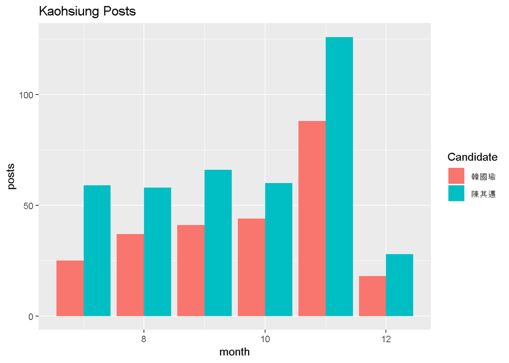

### Likes by Post Type

The below graph shows a summary of which type of posts by Kaohsiung mayoral candidates Han Guo-Yu (韓國瑜) and Chen Chi-Mai (陳其邁) received the most positive feedback, in terms of ‘likes’. From the figure we can see basic trends in audience response to the Kaohsiung City mayoral candidates. Although both candidates used multple types of content, both received the most positive response from posts which contained videos, followed by posts which contained photographs.In general Han Guo-Yu received a higher level of positive responses than Chen Chi-Mai.

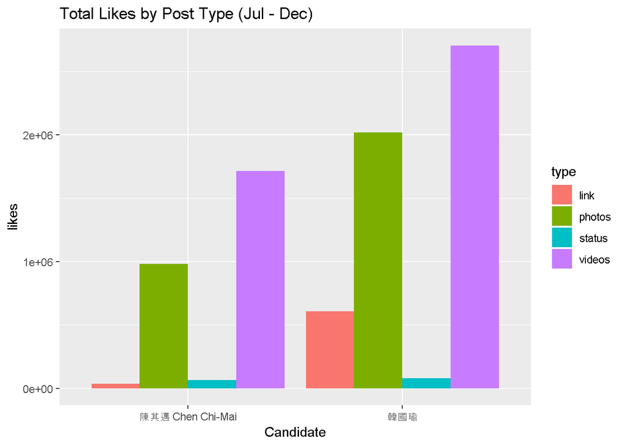

### Use of Opposition Candidates Name

The below graph shows the frequency by which the Kaohsiung mayoral candidates Han Guo-Yu (韓國瑜) and Chen Chi-Mai (陳其邁) used the name of their opponent in their Facebook post messages.

From the figure we can see basic trends. Both candidates used the name of their opponent.Han Guo-Yu’s reference to his opponent by name decreased over time, while Chen Chi-Mai’s references to his opponent increased over time.

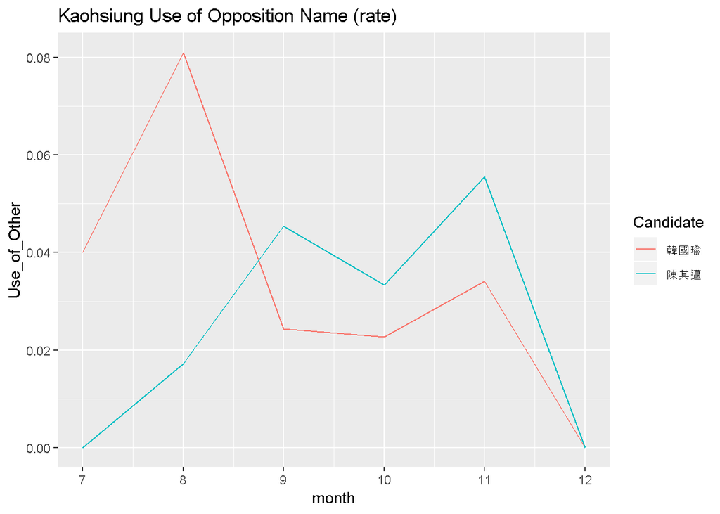

### Total likes (by week)

The below graph shows a summary of positive feedback, in terms of ‘likes’ for posts by Kaohsiung mayoral candidates Han Guo-Yu (韓國瑜) and Chen Chi-Mai (陳其邁).

From the figure we can see basic trends. Positive feedback for both candidates increased over time, however, Han Guo-Yu’s maintained a higher amount of positive feedback.

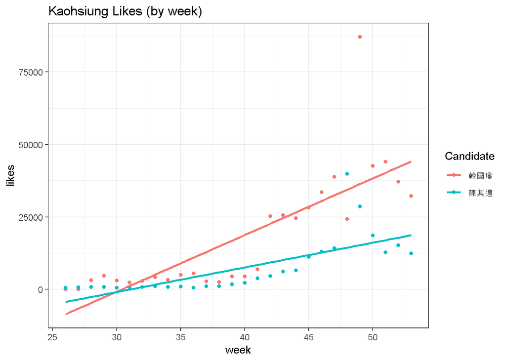

The below graph shows a summary of the relationship between message length and positive feedback, in terms of ‘likes’, for Kaohsiung mayoral candidates Han Guo-Yu (韓國瑜) and Chen Chi-Mai (陳其邁).

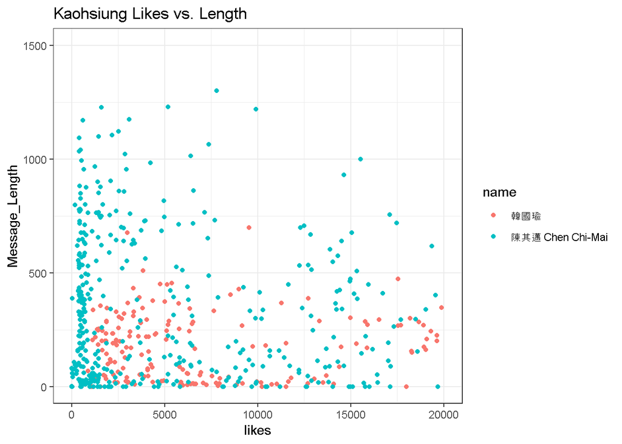